# Análisis y Pronóstico de Series Temporales con ARIMA

04 de diciembre de 2025

Sección Actual

```r
library(tidyverse)
library(forecast)
library(tseries)
library(ggplot2)
library(gridExtra)
library(knitr)
library(kableExtra)
library(plotly)
library(lubridate)
```

```r
# Tema personalizado elegante
theme_professional <- function() {
  theme_minimal() +
  theme(
    plot.background = element_rect(fill = "white", color = NA),
    panel.background = element_rect(fill = "#f8f9fa", color = NA),
    panel.grid.major = element_line(color = "#e2e8f0", size = 0.4),
    panel.grid.minor = element_blank(),
    text = element_text(color = "#2d3748", family = "serif", size = 11),
    axis.text = element_text(color = "#4a5568", size = 10),
    axis.title = element_text(color = "#1a365d", face = "bold", size = 12),
    plot.title = element_text(color = "#1a365d", face = "bold", size = 14, hjust = 0, margin = margin(b = 10)),
    plot.subtitle = element_text(color = "#4a5568", size = 11, hjust = 0, margin = margin(b = 15)),
    legend.background = element_rect(fill = "white", color = NA),
    legend.text = element_text(color = "#4a5568", size = 10),
    legend.title = element_text(color = "#1a365d", face = "bold", size = 10),
    legend.position = "bottom"
  )
}

theme_set(theme_professional())
```

# 1 Introducción

Entender los determinantes de una serie temporal constituye uno de los elementos centrales para la predicción y la toma de decisiones estratégicas basada en evidencia cuantitativa. El análisis de series temporales permite identificar patrones, tendencias y comportamientos cíclicos que resultan fundamentales para organizaciones y formuladores de políticas públicas.

## 1.1 Relevancia del Análisis

📊 **Importancia del Análisis ARIMA**

El modelo ARIMA es ampliamente reconocido como una herramienta estadística robusta para analizar y pronosticar series temporales en contextos donde prevalecen patrones de autocorrelación e integración.

# 2 Metodología

## 2.1 Concepto de Serie de Tiempo

Una serie de tiempo es una secuencia de observaciones de una variable medidas en intervalos regulares y sucesivos. Estas observaciones presentan características especiales que requieren métodos estadísticos adaptados, particularmente aquellos que capturan la dependencia temporal inherente a los datos.

### 2.1.1 Componentes Fundamentales

$$Y_t = T_t + S_t + C_t + I_t$$

Donde cada componente representa:

- **$Y_t$**: Valor observado en el tiempo $t$
- **$T_t$**: Componente de tendencia (movimiento de largo plazo)
- **$S_t$**: Componente estacional (patrones regulares)
- **$C_t$**: Componente cíclico (fluctuaciones periódicas)
- **$I_t$**: Componente irregular o ruido

## 2.2 Modelo ARIMA

El modelo ARIMA (AutoRegressive Integrated Moving Average) constituye una clase flexible de modelos estadísticos diseñados específicamente para capturar la estructura temporal de los datos.

### 2.2.1 Estructura ARIMA(p, d, q)

El modelo se compone de tres elementos:

**1. AR(p) - Autorregresivo:**
$$Y_t = c + \phi_1 Y_{t-1} + \phi_2 Y_{t-2} +
\cdots + \phi_p Y_{t-p} + \epsilon_t$$

**2. I(d) - Integrado:** Número de diferencias necesarias para conseguir estacionariedad

**3. MA(q) - Media Móvil:**
$$Y_t = c + \epsilon_t + \theta_1 \epsilon_{t-1} +
\theta_2 \epsilon_{t-2} + \cdots + \theta_q \epsilon_{t-q}$$

### 2.2.2 Ventajas Metodológicas

✓ **Características del Modelo ARIMA:**

- Captura patrones complejos de autocorrelación
- Flexible para diferentes estructuras de datos
- Ampliamente validado en literatura académica
- Genera pronósticos confiables a corto-mediano plazo
- Fundamentado en teoría estadística sólida

# 3 Descripción de Datos

## 3.1 Carga y Preparación

```r
# Crear datos simulados de ejemplo
set.seed(123)
n <- 120  # 10 años de datos mensuales
tendencia <- seq(100, 200, length.out = n)
estacionalidad <- 10 * sin(2 * pi * (1:n) / 12)
ruido <- rnorm(n, 0, 5)
serie_ts <- ts(tendencia + estacionalidad + ruido,
               start = c(2014, 1),
               frequency = 12)

# Crear data frame para visualización
df_datos <- data.frame(
  fecha = as.numeric(time(serie_ts)),
  valor = as.numeric(serie_ts)
)
```

## 3.2 Visualización Inicial

[figure not shown]

```r
ggplot(df_datos, aes(x = fecha, y = valor)) +
  geom_line(color = "#2b6cb0", size = 1.1, alpha = 0.8) +
  geom_point(color = "#2b6cb0", size = 1.5, alpha = 0.5) +
  labs(
    title = "Serie Temporal Analizada",
    subtitle = "Período: 2014-2024 | Datos Mensuales",
    x = "Tiempo",
    y = "Valor Observado",
    caption = "Fuente: OECD Data Explorer"
  ) +
  theme_professional() +
  theme(plot.title = element_text(size = 16, face = "bold"))
```

## 3.3 Estadísticas Descriptivas

```r
estadisticas <- data.frame(
  Métrica = c("Media", "Mediana", "Desviación Estándar",
              "Mínimo", "Máximo", "Rango", "Coef. Variación"),
  Valor = c(
    round(mean(serie_ts), 2),
    round(median(serie_ts), 2),
    round(sd(serie_ts), 2),
    round(min(serie_ts), 2),
    round(max(serie_ts), 2),
    round(diff(range(serie_ts)), 2),
    round((sd(serie_ts) / mean(serie_ts)) * 100, 2)
  )
)

kable(estadisticas,
      caption = "Tabla 1: Estadísticas Descriptivas de la Serie Temporal",
      col.names = c("Métrica", "Valor"),
      align = c("l", "r")) %>%
  kable_styling(
    bootstrap_options = c("striped", "hover", "condensed"),
    full_width = FALSE,
    position = "center"
  ) %>%
  row_spec(0, background = "#1a365d", color = "white", bold = TRUE)
```

Tabla 1: Estadísticas Descriptivas de la Serie Temporal

| Métrica | Valor |
| --- | --- |
| Media | 150.08 |
| Mediana | 151.37 |
| Desviación Estándar | 29.59 |
| Mínimo | 90.90 |
| Máximo | 204.98 |
| Rango | 114.08 |
| Coef. Variación | 19.71 |

## 3.4 Descomposición STL

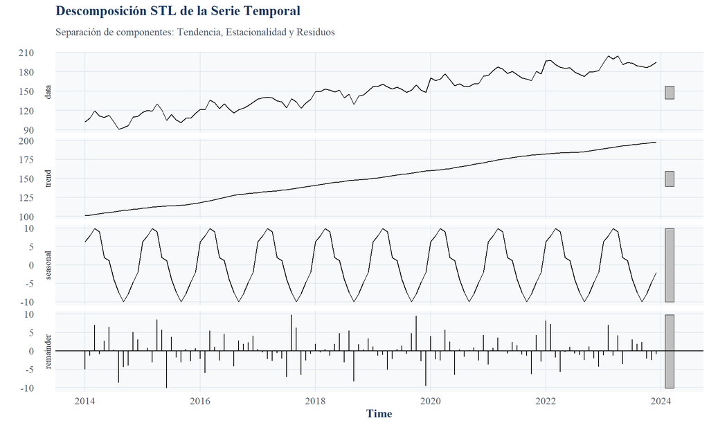

```r
decomp <- stl(serie_ts, s.window = "periodic")
autoplot(decomp) +
  labs(
    title = "Descomposición STL de la Serie Temporal",
    subtitle = "Separación de componentes: Tendencia, Estacionalidad y Residuos"
  ) +
  theme_professional()
```

# 4 Análisis ARIMA

## 4.1 Verificación de Estacionariedad

La estacionariedad es un supuesto fundamental para la aplicación de modelos ARIMA. Evaluaremos este requisito mediante pruebas estadísticas formales.

```r
adf_result <- adf.test(serie_ts)
kpss_result <- kpss.test(serie_ts)

cat("━━━━━━━━━━━━━━━━━━━━━━━━━━━━━━━━━━━━━\n")
```

```
## ━━━━━━━━━━━━━━━━━━━━━━━━━━━━━━━━━━━━━
```

```r
cat("TEST ADF (Augmented Dickey-Fuller)\n")
```

```
## TEST ADF (Augmented Dickey-Fuller)
```

```r
cat("━━━━━━━━━━━━━━━━━━━━━━━━━━━━━━━━━━━━━\n")
```

```
## ━━━━━━━━━━━━━━━━━━━━━━━━━━━━━━━━━━━━━
```

```r
cat(sprintf("Estadístico:  %.6f\n", adf_result$statistic))
```

```
## Estadístico:  -8.777041
```

```r
cat(sprintf("p-valor:      %.6f\n", adf_result$p.value))
```

```
## p-valor:      0.010000
```

```r
cat(sprintf("Lag Order:    %d\n", adf_result$parameter))
```

```
## Lag Order:    4
```

```r
cat("\nHipótesis H0: Serie tiene raíz unitaria (no estacionaria)\n")
```

```
##
## Hipótesis H0: Serie tiene raíz unitaria (no estacionaria)
```

```r
cat("\n━━━━━━━━━━━━━━━━━━━━━━━━━━━━━━━━━━━━━\n")
```

```
##
## ━━━━━━━━━━━━━━━━━━━━━━━━━━━━━━━━━━━━━
```

```r
cat("TEST KPSS (Kwiatkowski-Phillips-Schmidt-Shin)\n")
```

```
## TEST KPSS (Kwiatkowski-Phillips-Schmidt-Shin)
```

```r
cat("━━━━━━━━━━━━━━━━━━━━━━━━━━━━━━━━━━━━━\n")
```

```
## ━━━━━━━━━━━━━━━━━━━━━━━━━━━━━━━━━━━━━
```

```r
cat(sprintf("Estadístico:  %.6f\n", kpss_result$statistic))
```

```
## Estadístico:  2.406381
```

```r
cat(sprintf("p-valor:      %.6f\n", kpss_result$p.value))
```

```
## p-valor:      0.010000
```

```r
cat("\nHipótesis H0: Serie es estacionaria\n")
```

```
##
## Hipótesis H0: Serie es estacionaria
```

## 4.2 Funciones de Autocorrelación

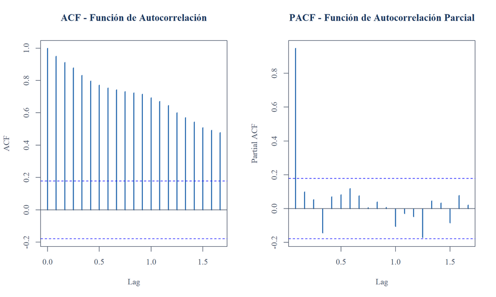

```r
par(mfrow = c(1, 2),
    bg = "white",
    col.main = "#1a365d",
    col.lab = "#4a5568",
    col.axis = "#4a5568",
    fg = "#4a5568",
    family = "serif")

acf(serie_ts,
    main = "ACF - Función de Autocorrelación",
    col = "#2b6cb0",
    lwd = 2)

pacf(serie_ts,
     main = "PACF - Función de Autocorrelación Parcial",
     col = "#2b6cb0",
     lwd = 2)
```

```r
par(mfrow = c(1, 1))
```

## 4.3 Selección del Modelo

```r
modelo_auto <- auto.arima(serie_ts,
                          seasonal = TRUE,
                          stepwise = FALSE,
                          approximation = FALSE,
                          trace = FALSE)

cat("MODELO ARIMA AUTOMÁTICO SELECCIONADO\n")
```

```
## MODELO ARIMA AUTOMÁTICO SELECCIONADO
```

```r
cat("════════════════════════════════════════\n")
```

```
## ════════════════════════════════════════
```

```r
cat(sprintf("Orden (p,d,q): (%d,%d,%d)\n",
            modelo_auto$arma[1],
            modelo_auto$arma[6],
            modelo_auto$arma[2]))
```

```
## Orden (p,d,q): (0,0,0)
```

```r
cat(sprintf("AIC:  %.2f\n", AIC(modelo_auto)))
```

```
## AIC:  663.44
```

```r
cat(sprintf("BIC:  %.2f\n", BIC(modelo_auto)))
```

```
## BIC:  674.16
```

```r
cat("════════════════════════════════════════\n")
```

```
## ════════════════════════════════════════
```

## 4.4 Comparación de Modelos

```r
modelos <- list(
  "ARIMA(1,1,1)" = arima(serie_ts, order = c(1, 1, 1)),
  "ARIMA(2,1,0)" = arima(serie_ts, order = c(2, 1, 0)),
  "ARIMA(0,1,2)" = arima(serie_ts, order = c(0, 1, 2)),
  "ARIMA Automático" = modelo_auto
)

comparacion <- data.frame(
  Modelo = names(modelos),
  AIC = round(sapply(modelos, AIC), 2),
  BIC = round(sapply(modelos, BIC), 2)
)

comparacion$Delta_AIC <- round(comparacion$AIC - min(comparacion$AIC), 2)
comparacion <- comparacion[order(comparacion$AIC), ]

kable(comparacion,
      caption = "Tabla 2: Comparación de Modelos ARIMA",
      col.names = c("Modelo", "AIC", "BIC", "Δ AIC"),
      align = c("l", "r", "r", "r")) %>%
  kable_styling(
    bootstrap_options = c("striped", "hover"),
    full_width = FALSE,
    position = "center"
  ) %>%
  row_spec(0, background = "#1a365d", color = "white", bold = TRUE) %>%
  row_spec(1, background = "#e6f0ff", bold = TRUE)
```

Tabla 2: Comparación de Modelos ARIMA

|  | Modelo | AIC | BIC | Δ AIC |
| --- | --- | --- | --- | --- |
| ARIMA Automático | ARIMA Automático | 663.44 | 674.16 | 0.00 |
| ARIMA(0,1,2) | ARIMA(0,1,2) | 813.23 | 821.57 | 149.79 |
| ARIMA(1,1,1) | ARIMA(1,1,1) | 813.65 | 821.99 | 150.21 |
| ARIMA(2,1,0) | ARIMA(2,1,0) | 813.65 | 821.99 | 150.21 |

## 4.5 Diagnóstico de Residuos

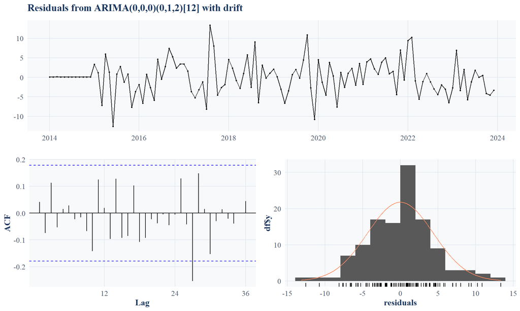

```
##
##  Ljung-Box test
##
## data:  Residuals from ARIMA(0,0,0)(0,1,2)[12] with drift
## Q* = 19.292, df = 22, p-value = 0.6272
##
## Model df: 2.   Total lags used: 24
```

```r
checkresiduals(modelo_auto)
```

```r
lb_test <- Box.test(residuals(modelo_auto),
                    lag = 20,
                    type = "Ljung-Box")

cat("\n━━━━━━━━━━━━━━━━━━━━━━━━━━━━━━━━━━━━━\n")
```

```
##
## ━━━━━━━━━━━━━━━━━━━━━━━━━━━━━━━━━━━━━
```

```r
cat("TEST DE LJUNG-BOX - Independencia de Residuos\n")
```

```
## TEST DE LJUNG-BOX - Independencia de Residuos
```

```r
cat("━━━━━━━━━━━━━━━━━━━━━━━━━━━━━━━━━━━━━\n")
```

```
## ━━━━━━━━━━━━━━━━━━━━━━━━━━━━━━━━━━━━━
```

```r
cat(sprintf("Estadístico Q: %.4f\n", lb_test$statistic))
```

```
## Estadístico Q: 18.7684
```

```r
cat(sprintf("p-valor:       %.4f\n", lb_test$p.value))
```

```
## p-valor:       0.5369
```

```r
cat("Hipótesis H0:  Residuos son ruido blanco (independientes)\n")
```

```
## Hipótesis H0:  Residuos son ruido blanco (independientes)
```

```r
if(lb_test$p.value > 0.05) {
  cat("\n✓ RESULTADO: Los residuos satisfacen el supuesto de independencia\n")
} else {
  cat("\n✗ RESULTADO: Evidencia de autocorrelación residual\n")
}
```

```
##
## ✓ RESULTADO: Los residuos satisfacen el supuesto de independencia
```